# Conservation inter-espèces de microARN et choix de modèle animal

myomiRs cardiaques/musculaires (miR-1, miR-133a, miR-208a/b, miR-499a) et let-7a

Romain KPAKOU

16 September 2026

## Contexte

Étude de la conservation inter-espèces d’un panel de microARN musculaires/cardiaques (“myomiRs”) – *miR-1*, *miR-133a*, *miR-208a*, *miR-208b*, *miR-499a* – et de *let-7a* comme référence de conservation profonde. Panel choisi pour sa cohérence avec les projets précédents de cette série centrés sur la génomique cardiaque (*MYH7* dans le panel CNV, RNA-seq cardiaque ENCODE) : *miR-208a* et *miR-208b* sont respectivement nichés dans un intron des gènes *MYH6* et *MYH7*. Voir README et PLAN.md pour la méthodologie complète.

Pipeline entièrement automatisé et paramétré par liste de miARN (`scripts/00_extract_sequences.py`) – reproductible pour tout autre miARN présent dans miRBase sans modification du code.

## Étendue de la conservation par famille

| Famille | Espèces (miRBase) | Clades présents | Identité globale moyenne (%) | Identité seed moyenne (%) |
| --- | --- | --- | --- | --- |
| let-7a-5p | 74 | Actinopterygii;Amphibia;Autre;Aves;Insecta;Mammalia | 97.7 | 99.8 |
| miR-1-3p | 119 | Actinopterygii;Autre;Aves;Insecta;Mammalia;Nematoda | 95.0 | 99.4 |
| miR-133a-3p | 55 | Actinopterygii;Amphibia;Autre;Aves;Mammalia | 99.8 | 100.0 |
| miR-208a-3p | 20 | Autre;Mammalia | 97.5 | 100.0 |
| miR-208b-3p | 23 | Autre;Mammalia | 97.0 | 100.0 |
| miR-499a-5p | 6 | Actinopterygii;Mammalia | 99.2 | 100.0 |

La colonne “seed” (positions 2-8 de la séquence mature – le segment le plus déterminant pour la reconnaissance des ARNm cibles) est systématiquement **plus conservée** que la séquence globale pour les 6 familles, cohérent avec une pression de sélection purificatrice plus forte sur la seed que sur le reste de la séquence mature.

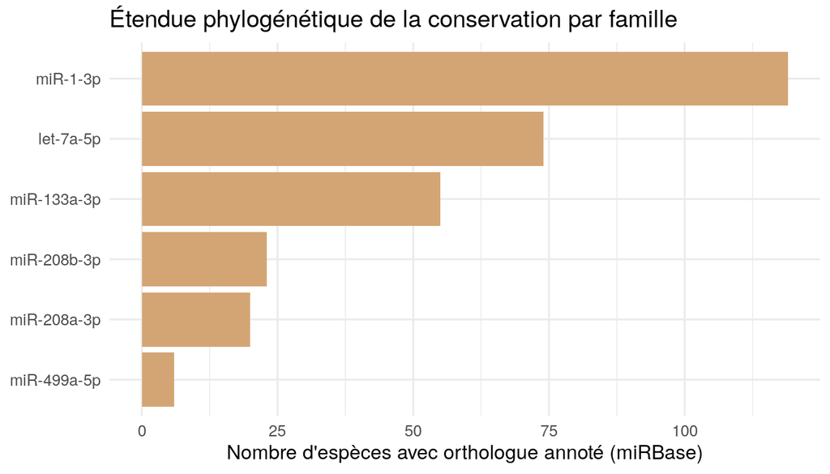

## Conservation de la seed region vs séquence globale

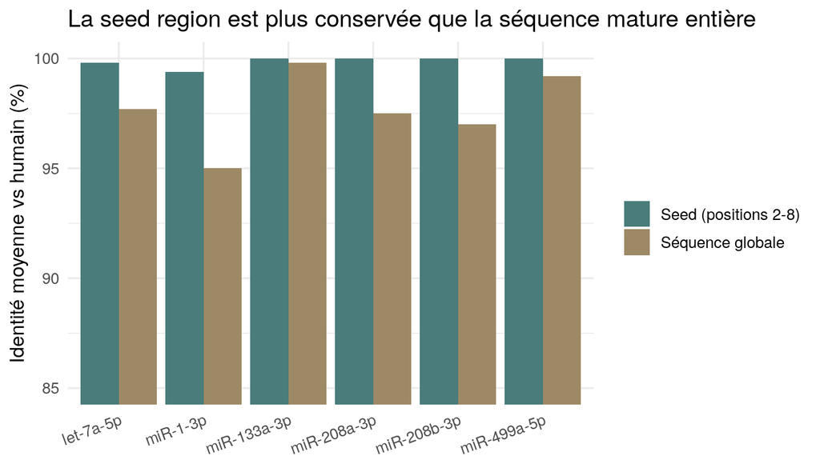

## Recommandation de modèle animal par miARN

| Famille | Modèles disponibles | Modèle recommandé | Identité (%) | Alternatives |
| --- | --- | --- | --- | --- |
| let-7a-5p | 5 | Souris (Mus musculus) | 100 | Rat (Rattus norvegicus) (100.0%), Poulet (Gallus gallus) (100.0%), Poisson-zèbre (Danio rerio) (100.0%) |
| miR-1-3p | 4 | Nématode (Caenorhabditis elegans) | 100 | Poisson-zèbre (Danio rerio) (100.0%), Rat (Rattus norvegicus) (95.5%), Drosophile (Drosophila melanogaster) (90.9%) |
| miR-133a-3p | 4 | Souris (Mus musculus) | 100 | Poulet (Gallus gallus) (100.0%), Poisson-zèbre (Danio rerio) (100.0%), Xénope (Xenopus tropicalis) (100.0%) |
| miR-208a-3p | 2 | Souris (Mus musculus) | 100 | Rat (Rattus norvegicus) (100.0%) |
| miR-208b-3p | 2 | Souris (Mus musculus) | 100 | Rat (Rattus norvegicus) (100.0%) |
| miR-499a-5p | 0 | Aucun modèle de laboratoire courant disponible | NA | NA |

La souris est recommandée pour 4 des 6 familles (identité 100 % sur la séquence mature). Pour *miR-1*, le nématode *C. elegans* et le poisson-zèbre sont à égalité parfaite (100 %) – un exemple frappant de conservation de séquence sur des centaines de millions d’années d’évolution.

**Cas particulier : *miR-499a-5p*.** Aucun modèle de laboratoire standard (souris, rat, poisson-zèbre, poulet) n’est annoté dans miRBase pour ce miARN, alors que le gène *MYH7B* qui l’héberge existe bien chez la souris. Il s’agit très probablement d’une **lacune d’annotation de miRBase** plutôt que d’une absence biologique réelle – un point de vigilance à ne pas confondre avec une conclusion de conservation (absence de preuve n’est pas preuve d’absence).

## Détail : conservation de *miR-1-3p*

| Code espèce | Espèce | Clade | Identité globale (%) | Identité seed (%) |
| --- | --- | --- | --- | --- |
| cel | Caenorhabditis elegans | Nematoda | 100 | 100 |
| cbr | Caenorhabditis briggsae | Nematoda | 100 | 100 |
| dre | Danio rerio | Actinopterygii | 100 | 100 |
| ppa | Pan paniscus | Mammalia | 100 | 100 |
| fru | Fugu rubripes | Actinopterygii | 100 | 100 |
| mdo | Monodelphis domestica | Mammalia | 100 | 100 |
| mml | Macaca mulatta | Mammalia | 100 | 100 |
| cfa | Canis lupus familiaris | Mammalia | 100 | 100 |
| ptr | Pan troglodytes | Mammalia | 100 | 100 |
| bta | Bos taurus | Mammalia | 100 | 100 |
| bfl | Branchiostoma floridae | Autre | 100 | 100 |
| lgi | Lottia gigantea | Autre | 100 | 100 |
| spu | Strongylocentrotus purpuratus | Autre | 100 | 100 |
| ssc | Sus scrofa | Mammalia | 100 | 100 |
| crm | Caenorhabditis remanei | Nematoda | 100 | 100 |

Note méthodologique : *miR-1* existe en deux copies génomiques chez l’humain (*MIR1-1*/*MIR1-2*) ; miRBase annote le produit mature sous un nom incluant le numéro de locus (`hsa-miR-1-2-3p`) plutôt que le nom de famille simple. Ce cas a été détecté et géré automatiquement par le pipeline (voir `scripts/00_extract_sequences.py`).

## Croisement avec l’orthologie Ensembl Compara

La conservation de séquence (ci-dessus) peut en principe refléter une similarité fortuite plutôt qu’une vraie orthologie. Pour les 3 miARN à locus génomique humain unique et non ambigu (*MIR208A*, *MIR208B*, *MIR499A* – *miR-1*, *miR-133a* et *let-7a* existant en plusieurs copies paralogues chez l’humain, un croisement à gène Ensembl unique serait arbitraire pour ces trois-là), l’orthologie annotée par Ensembl Compara confirme la conservation observée :

| Famille | Gène Ensembl | Espèce cible | Type d’homologie | Identité (niveau gène, %) | Niveau taxonomique |
| --- | --- | --- | --- | --- | --- |
| miR-208a-3p | ENSG00000199157 | mus_musculus | ortholog_one2one | 81.9277 | Eutheria |
| miR-208a-3p | ENSG00000199157 | rattus_norvegicus | ortholog_one2one | 42.2414 | Eutheria |
| miR-208a-3p | ENSG00000199157 | danio_rerio | ortholog_one2one | 57.5000 | Euteleostomi |
| miR-208b-3p | ENSG00000215991 | mus_musculus | ortholog_one2one | 94.8052 | Eutheria |

*MIR208A* a un orthologue confirmé (`ortholog_one2one`) jusque chez le poisson-zèbre – plus large que ce que suggérait l’extraction miRBase seule (aucune séquence mature zebrafish n’y était annotée pour ce miARN), signe que les deux bases de données ne sont pas parfaitement synchronisées. **Aucun orthologue Compara n’est trouvé pour *MIR499A* chez la souris, le rat, le poulet ou le poisson-zèbre** – ceci corrobore, de façon indépendante, l’absence déjà constatée dans miRBase (voir section précédente), et renforce l’hypothèse d’une réelle limite de détection plutôt que d’une simple lacune isolée d’une seule base.

## Choix méthodologique : identité de séquence plutôt que dN/dS

Le plan initial envisageait un score de pression de sélection type dN/dS. Les microARN matures étant des ARN **non codants**, la distinction substitutions synonymes/non- synonymes ne s’applique pas à leur séquence. Le score retenu est l’**identité de séquence par rapport à l’orthologue humain**, calculée sur l’alignement multiple MAFFT (colonnes sans gap uniquement) – la mesure standard et appropriée pour des séquences non codantes courtes.

## Limites

- Séquences matures très courtes (20-23 nt) : chaque substitution représente 4-5 points de pourcentage d’identité, la mesure est donc grossière à cette échelle.
- L’absence d’un orthologue dans miRBase pour une espèce donnée peut refléter une lacune d’annotation plutôt qu’une absence biologique réelle (cas de *miR-499a-5p* chez la souris, voir ci-dessus).
- La classification taxonomique par grand clade (via NCBI Taxonomy) regroupe sous “Autre” des lignées non subdivisées plus finement (reptiles, invertébrés hors Insecta/Nematoda, tuniciers…) – suffisant pour cette analyse mais pas une taxonomie complète.
- Le croisement Ensembl Compara ne couvre que 3 des 6 familles (locus génomique humain unique requis) et seulement 4 espèces cibles (souris, rat, poulet, poisson-zèbre) – pas une confirmation d’orthologie exhaustive sur l’ensemble du panel.

## Reproductibilité

```bash
./scripts/run_all.sh
```